# Trabalho final - Coleta e Análise de Dados Secundários

## Análises sobre a mortalidade causada pelo câncer no Brasil

Dados do Sistema de Informações sobre Mortalidade (SIM), do Ministério da Saúde, indicam que os diferentes tipos de câncer correspondem à segunda maior causa de mortes por doenças no Brasil, ficando atrás apenas das doenças relacionadas ao aparelho circulatório. Um estudo recente (Luzzati e outros, 2018) utilizou informações de 122 países e concluiu que há correlação positiva e significante entre desenvolvimento econômico e incidência de câncer. Isso indica que há uma tendência de que o câncer tenha impacto crescente sobre a saúde da população mundial nas próximas décadas (Ferlay e outros, 2012). Em consonância com isso, um estudo feito pelo Observatório de Oncologia da Associação Brasileira de Leucemia e Linfoma indica que o câncer pode se tornar a principal causa de mortes no Brasil em 2029.

## OBJETIVO

A Política Nacional para Prevenção e Combate ao Câncer, do Ministério da Saúde, tem como um dos principais objetivos a redução da mortalidade causada pelo câncer. Nesse sentido, o objetivo desse trabalho é analisar questões relacionadas ao aumento da mortalidade causada pelo câncer no Brasil.

## INSTALANDO PACOTES

Utilizando o macetinho, foram instalados os pacotes utilizados na disciplina:

```r
lista.de.pacotes = c("tidyverse","lubridate","janitor","readxl","stringr","repmis") #
novos.pacotes <- lista.de.pacotes[!(lista.de.pacotes %in%
                                      installed.packages()[,"Package"])]
if(length(novos.pacotes) > 0) {install.packages(novos.pacotes)}
lapply(lista.de.pacotes, require, character.only=T)
```

```
## [[1]]
## [1] TRUE
##
## [[2]]
## [1] TRUE
##
## [[3]]
## [1] TRUE
##
## [[4]]
## [1] TRUE
##
## [[5]]
## [1] TRUE
##
## [[6]]
## [1] TRUE
```

```r
rm(lista.de.pacotes,novos.pacotes)
gc()
```

```
##           used (Mb) gc trigger (Mb) max used (Mb)
## Ncells  853615 45.6    1692384 90.4  1188455 63.5
## Vcells 1465729 11.2    8388608 64.0  2033789 15.6
```

```r
library(tidyverse)
```

## EXTRAÇÃO DOS DADOS E IMPORTAÇÃO PARA O R

Os dados sobre mortalidade utilizados nas análises a seguir foram extraídos da plataforma tabnet (http://tabnet.datasus.gov.br/). Nessa extração, foram identificadas os registros totais de mortes e os registros de mortes causadas por neoplasias (câncer), por município.

Os arquivos extraídos do tabnet foram lidos no ambiente R, conforme a seguir:

```r
library(readr)
mortalidade_2016 <- read_csv2("~/trabalho_final/mortalidade_2016.csv")
```

```
## Using ',' as decimal and '.' as grouping mark. Use read_delim() for more control.
```

```r
mortalidade_2001 <- read_csv2("~/trabalho_final/mortalidade_2001.csv")
```

```
## Using ',' as decimal and '.' as grouping mark. Use read_delim() for more control.
```

Depois da importação, foi criado um novo objeto contendo informações sobre os dois arquivos importados, excluída a coluna repetida (nome do município)

```r
mortalidade <- mortalidade_2016 %>%
  inner_join(mortalidade_2001, "cod_ibge") %>%
  select(-nome_mun.y)
```

Depois, foi importado um arquivo contendo dados do Índice de desenvolvimento humano municipal (IDHM)calculado pelo PNUD, IPEA e Fundação João Pinheiro com base nos dados dos censos do IBGE:

```r
IDHM <- read_csv2("~/trabalho_final/IDHM.csv")
```

```
## Using ',' as decimal and '.' as grouping mark. Use read_delim() for more control.
```

O novo objeto criado foi juntado aos dados de mortalidade, criando-se um novo objeto denominado "mortalidade_idhm", que será utilizado para as análises

```r
mortalidade_idhm <- mortalidade %>%
  inner_join(IDHM, "cod_ibge") %>%
  select(-nome_mun)
```

## Alterando colunas

Foi necessário transformar as mortes_cancer_2016 e mortes_cancer_2001 em numéricas:

```r
mortalidade_idhm <- mortalidade_idhm %>%
  mutate(mortes_cancer_2016 = as.numeric(mortes_cancer_2016)) %>%
  mutate(mortes_cancer_2001 = as.numeric(mortes_cancer_2001))
```

## ADICIONANDO DADOS…

Para facilitar a análise, foram criadas duas novas colunas, contendo as siglas dos Estados e os nomes das Regiões:

```r
mortalidade_idhm <- mortalidade_idhm %>%
  mutate(nome_UF=case_when(
    UF=="11"~"RO",UF=="12"~"AC",UF=="13"~"AM",UF=="14"~"RR",UF=="15"~"PA",UF=="16"~"AP",UF=="17"~"TO",UF=="21"~"MA",
    UF=="22"~"PI",UF=="23"~"CE",UF=="24"~"RN", UF=="25"~"PB",UF=="26"~"PE",UF=="27"~"AL",UF=="28"~"SE",UF=="29"~"BA",
    UF=="31"~"MG",UF=="32"~"ES",UF=="33"~"RJ",UF=="35"~"SP",UF=="41"~"PR",UF=="42"~"SC",UF=="43"~"RS",UF=="50"~"MS",
    UF=="51"~"MT",UF=="52"~"GO",UF=="53"~"DF")
    )
```

```r
mortalidade_idhm <- mortalidade_idhm %>%
  mutate(regiao=case_when(
    UF=="11"~"Norte",UF=="12"~"Norte",UF=="13"~"Norte",UF=="14"~"Norte",UF=="15"~"Norte",UF=="16"~"Norte",
    UF=="17"~"Norte",UF=="21"~"Nordeste",UF=="22"~"Nordeste",UF=="23"~"Nordeste",UF=="24"~"Nordeste",UF=="25"~"Nordeste",
    UF=="26"~"Nordeste",UF=="27"~"Nordeste",UF=="28"~"Nordeste",UF=="29"~"Nordeste",UF=="31"~"Sudeste",UF=="32"~"Sudeste",
    UF=="33"~"Sudeste",UF=="35"~"Sudeste",UF=="41"~"Sul",UF=="42"~"Sul",UF=="43"~"Sul",UF=="50"~"Centro-Oeste",
    UF=="51"~"Centro-Oeste",UF=="52"~"Centro-Oeste",UF=="53"~"Centro-Oeste")
  )
```

## ADICIONANDO DADOS…

Foram criadas duas colunas que indicam a proporção de mortes por câncer no total de mortes em cada ano (2001 e 2016):

```r
mortalidade_idhm <- mortalidade_idhm %>%
  mutate(prop_cancer_2016=mortes_cancer_2016/mortes_total_2016) %>%
  mutate(prop_cancer_2001=mortes_cancer_2001/mortes_total_2001)
```

Foi criada, também, uma coluna que indica se houve aumento na proporção de mortes causadas pelo câncer entre 2001 e 2016:

```r
mortalidade_idhm <- mortalidade_idhm %>%
  mutate(aumento_cancer=case_when(
    prop_cancer_2016>prop_cancer_2001~"Sim",
    prop_cancer_2016<prop_cancer_2001~"Nao"))
```

## ADICIONANDO DADOS…

Foi criada uma variável numérica com atributo = 1 para contar a quantidade de municípios

```r
mortalidade_idhm <- mortalidade_idhm %>%
  mutate(var_teste = 1)
```

Foram excluídos os casos de N/A

```r
mortalidade_idhm <- mortalidade_idhm %>%
  filter(!is.na(aumento_cancer))
```

## Analisando…

A mortalidade causada pelo câncer é superior a 40% do total de mortes registradas em 2016 em 8 municípios:

```r
mortalidade_idhm %>%
  filter(prop_cancer_2016>0.4) %>%
  count()
```

```
## # A tibble: 1 x 1
##       n
##   <int>
## 1     8
```

## Analisando…

O gráfico a seguir indica quantos municípios reduziram a mortalidade causada pelo câncer no período analisado, por regiões.

```r
grafico <- mortalidade_idhm %>%
  group_by(regiao) %>%
  ggplot(aes(x=regiao,
             y=var_teste,
             fill=aumento_cancer,
             color=aumento_cancer)) +
  geom_bar(stat = "identity")+
  ylab("Qtde Municípios")+
  xlab("Regiões")+
  theme(legend.position = "top")
```

Gráfico no slide seguinte…

## Analisando…

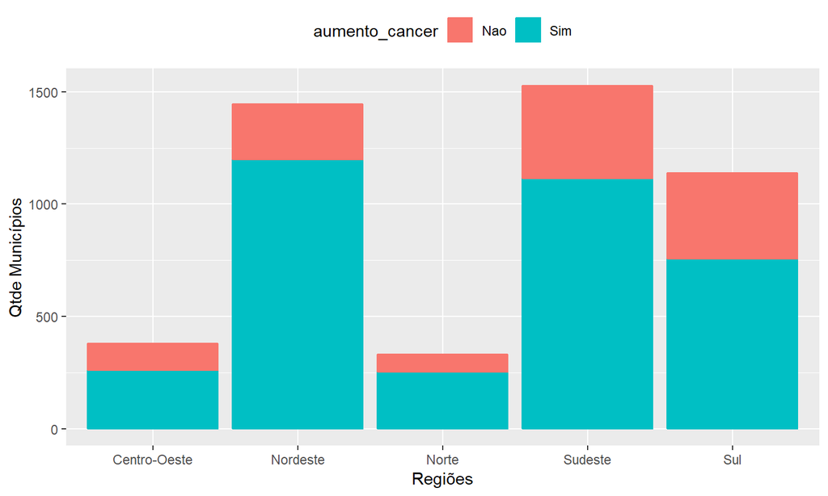

```r
grafico
```

## Analisando

O gráfico seguinte indica a proporção de mortes causadas pelo câncer agrupados por UF, incluindo os "outliers":

```r
grafico3 <- mortalidade_idhm %>%
  group_by(nome_UF) %>%
  ggplot(aes(x=nome_UF,
             y=prop_cancer_2016))+
  geom_boxplot(fill="slateblue", alpha=0.2)
```

Gráfico no slide seguinte…

## Analisando…

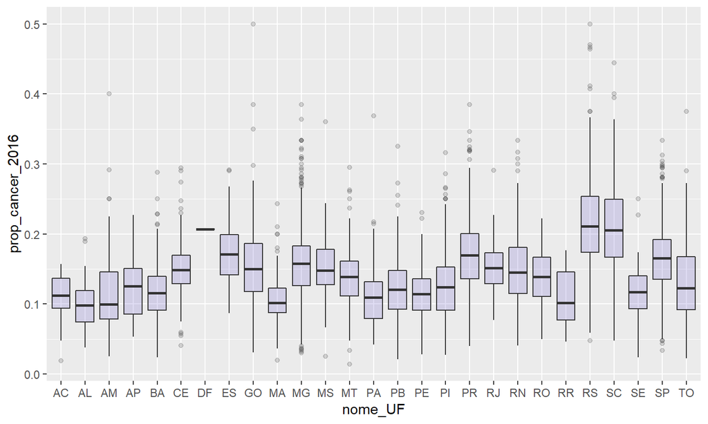

```r
grafico3
```

## Analisando…

Já o gráfico a seguir indica a correlação entre a mortalidade causada pelo câncer e o IDHM do município.

```r
grafico2 <- mortalidade_idhm %>%
  ggplot(aes(x=IDHM2010, y=prop_cancer_2016, color=prop_cancer_2016))+
  geom_point()
```

Gráfico no slide seguinte…

## Analisando…

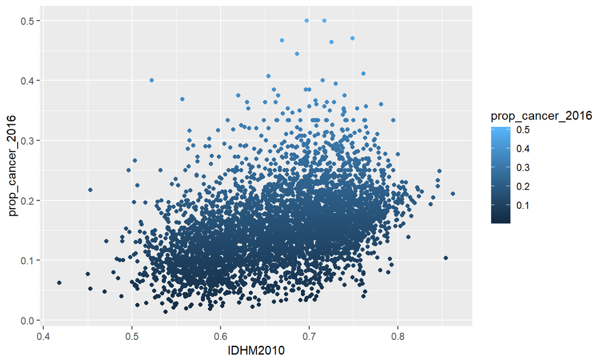

```r
grafico2
```

Por fim, foi calculada a correlação entre essas duas variáveis:

```r
cor.test(mortalidade_idhm$IDHM2010, mortalidade_idhm$prop_cancer_2016)
```

```
##
##  Pearson's product-moment correlation
##
## data:  mortalidade_idhm$IDHM2010 and mortalidade_idhm$prop_cancer_2016
## t = 32.766, df = 4821, p-value < 2.2e-16
## alternative hypothesis: true correlation is not equal to 0
## 95 percent confidence interval:
##  0.4034024 0.4495753
## sample estimates:
##       cor
## 0.4267669
```